# bellabeat

Folami

8/23/2022

## FitBit Fitness Tracker Data

### Data wrangling

The project involves analyzing the usage of smart devices in order to direct market strategy. Data for this exercise was obtained from Kaggle: [FitBit Fitness Tracker.](https://www.kaggle.com/datasets/arashnic/fitbit)

Following the download of the files, libraries were loaded

```r
#load libraries

library(tidyverse)
library(janitor)
```

The *dailyActivity_merged* and *sleepday_merged* table were imported using the *readr* package and examined.

```r
#import tables and check the tables

daily_activity <- read_csv("dailyActivity_merged.csv")
glimpse(daily_activity)
```

```
## Rows: 940
## Columns: 15
## $ Id                       <dbl> 1503960366, 1503960366, 1503960366, 150396036~
## $ ActivityDate             <chr> "4/12/2016", "4/13/2016", "4/14/2016", "4/15/~
## $ TotalSteps               <dbl> 13162, 10735, 10460, 9762, 12669, 9705, 13019~
## $ TotalDistance            <dbl> 8.50, 6.97, 6.74, 6.28, 8.16, 6.48, 8.59, 9.8~
## $ TrackerDistance          <dbl> 8.50, 6.97, 6.74, 6.28, 8.16, 6.48, 8.59, 9.8~
## $ LoggedActivitiesDistance <dbl> 0, 0, 0, 0, 0, 0, 0, 0, 0, 0, 0, 0, 0, 0, 0, ~
## $ VeryActiveDistance       <dbl> 1.88, 1.57, 2.44, 2.14, 2.71, 3.19, 3.25, 3.5~
## $ ModeratelyActiveDistance <dbl> 0.55, 0.69, 0.40, 1.26, 0.41, 0.78, 0.64, 1.3~
## $ LightActiveDistance      <dbl> 6.06, 4.71, 3.91, 2.83, 5.04, 2.51, 4.71, 5.0~
## $ SedentaryActiveDistance  <dbl> 0, 0, 0, 0, 0, 0, 0, 0, 0, 0, 0, 0, 0, 0, 0, ~
## $ VeryActiveMinutes        <dbl> 25, 21, 30, 29, 36, 38, 42, 50, 28, 19, 66, 4~
## $ FairlyActiveMinutes      <dbl> 13, 19, 11, 34, 10, 20, 16, 31, 12, 8, 27, 21~
## $ LightlyActiveMinutes     <dbl> 328, 217, 181, 209, 221, 164, 233, 264, 205, ~
## $ SedentaryMinutes         <dbl> 728, 776, 1218, 726, 773, 539, 1149, 775, 818~
## $ Calories                 <dbl> 1985, 1797, 1776, 1745, 1863, 1728, 1921, 203~
```

```r
str(daily_activity)
```

```
## spec_tbl_df [940 x 15] (S3: spec_tbl_df/tbl_df/tbl/data.frame)
##  $ Id                      : num [1:940] 1.5e+09 1.5e+09 1.5e+09 1.5e+09 1.5e+09 ...
##  $ ActivityDate            : chr [1:940] "4/12/2016" "4/13/2016" "4/14/2016" "4/15/2016" ...
##  $ TotalSteps              : num [1:940] 13162 10735 10460 9762 12669 ...
##  $ TotalDistance           : num [1:940] 8.5 6.97 6.74 6.28 8.16 ...
##  $ TrackerDistance         : num [1:940] 8.5 6.97 6.74 6.28 8.16 ...
##  $ LoggedActivitiesDistance: num [1:940] 0 0 0 0 0 0 0 0 0 0 ...
##  $ VeryActiveDistance      : num [1:940] 1.88 1.57 2.44 2.14 2.71 ...
##  $ ModeratelyActiveDistance: num [1:940] 0.55 0.69 0.4 1.26 0.41 ...
##  $ LightActiveDistance     : num [1:940] 6.06 4.71 3.91 2.83 5.04 ...
##  $ SedentaryActiveDistance : num [1:940] 0 0 0 0 0 0 0 0 0 0 ...
##  $ VeryActiveMinutes       : num [1:940] 25 21 30 29 36 38 42 50 28 19 ...
##  $ FairlyActiveMinutes     : num [1:940] 13 19 11 34 10 20 16 31 12 8 ...
##  $ LightlyActiveMinutes    : num [1:940] 328 217 181 209 221 164 233 264 205 211 ...
##  $ SedentaryMinutes        : num [1:940] 728 776 1218 726 773 ...
##  $ Calories                : num [1:940] 1985 1797 1776 1745 1863 ...
##  - attr(*, "spec")=
##   .. cols(
##   ..   Id = col_double(),
##   ..   ActivityDate = col_character(),
##   ..   TotalSteps = col_double(),
##   ..   TotalDistance = col_double(),
##   ..   TrackerDistance = col_double(),
##   ..   LoggedActivitiesDistance = col_double(),
##   ..   VeryActiveDistance = col_double(),
##   ..   ModeratelyActiveDistance = col_double(),
##   ..   LightActiveDistance = col_double(),
##   ..   SedentaryActiveDistance = col_double(),
##   ..   VeryActiveMinutes = col_double(),
##   ..   FairlyActiveMinutes = col_double(),
##   ..   LightlyActiveMinutes = col_double(),
##   ..   SedentaryMinutes = col_double(),
##   ..   Calories = col_double()
##   .. )
##  - attr(*, "problems")=<externalptr>
```

```r
sleep_day <- read_csv("sleepDay_merged.csv")
head(sleep_day)
```

```
## # A tibble: 6 x 5
##           Id SleepDay           TotalSleepRecor~ TotalMinutesAsl~ TotalTimeInBed
##        <dbl> <chr>                         <dbl>            <dbl>          <dbl>
## 1 1503960366 4/12/2016 12:00:0~                1              327            346
## 2 1503960366 4/13/2016 12:00:0~                2              384            407
## 3 1503960366 4/15/2016 12:00:0~                1              412            442
## 4 1503960366 4/16/2016 12:00:0~                2              340            367
## 5 1503960366 4/17/2016 12:00:0~                1              700            712
## 6 1503960366 4/19/2016 12:00:0~                1              304            320
```

The *ActivityDate* variable (2nd column) of the *daily_activity* was then formatted from string to date (“double”).

```r
#change the format and convert to date type
as.Date(daily_activity$ActivityDate, format= "%m/%d/%Y") -> activitydate
head(activitydate)
```

```
## [1] "2016-04-12" "2016-04-13" "2016-04-14" "2016-04-15" "2016-04-16"
## [6] "2016-04-17"
```

```r
# to check the data_type
typeof(activitydate)
```

```
## [1] "double"
```

```r
#replace the ActivityDate column with the new date format
daily_activity$ActivityDate <- activitydate
head(daily_activity)
```

```
## # A tibble: 6 x 15
##        Id ActivityDate TotalSteps TotalDistance TrackerDistance LoggedActivitie~
##     <dbl> <date>            <dbl>         <dbl>           <dbl>            <dbl>
## 1  1.50e9 2016-04-12        13162          8.5             8.5                 0
## 2  1.50e9 2016-04-13        10735          6.97            6.97                0
## 3  1.50e9 2016-04-14        10460          6.74            6.74                0
## 4  1.50e9 2016-04-15         9762          6.28            6.28                0
## 5  1.50e9 2016-04-16        12669          8.16            8.16                0
## 6  1.50e9 2016-04-17         9705          6.48            6.48                0
## # ... with 9 more variables: VeryActiveDistance <dbl>,
## #   ModeratelyActiveDistance <dbl>, LightActiveDistance <dbl>,
## #   SedentaryActiveDistance <dbl>, VeryActiveMinutes <dbl>,
## #   FairlyActiveMinutes <dbl>, LightlyActiveMinutes <dbl>,
## #   SedentaryMinutes <dbl>, Calories <dbl>
```

The *sleepDay* column of the *sleep_day* was also formated

```r
sleepday <- as.POSIXct(sleep_day$SleepDay, format= "%m/%d/%Y %H:%M:%S")
sleep_day$SleepDay <- as.Date(sleepday)
head(sleep_day)
```

```
## # A tibble: 6 x 5
##           Id SleepDay   TotalSleepRecords TotalMinutesAsleep TotalTimeInBed
##        <dbl> <date>                 <dbl>              <dbl>          <dbl>
## 1 1503960366 2016-04-12                 1                327            346
## 2 1503960366 2016-04-13                 2                384            407
## 3 1503960366 2016-04-15                 1                412            442
## 4 1503960366 2016-04-16                 2                340            367
## 5 1503960366 2016-04-17                 1                700            712
## 6 1503960366 2016-04-19                 1                304            320
```

```r
n_distinct(daily_activity$Id)
```

```
## [1] 33
```

```r
n_distinct(sleep_day$Id)
```

```
## [1] 24
```

The tables were then joined using the full join. The tables were joined on the id and date variables of the respective tables. a new table: *merged_dataset* was formed.

```r
merged_dataset <- full_join(daily_activity, sleep_day, by = c("Id" = "Id", "ActivityDate" = "SleepDay"))
```

After merging the data, further cleaning was done. Id was converted to character data type from number.

```r
#change the Id data_type and remove duplicates.

merged_dataset$Id <- as.character(merged_dataset$Id)

merged_dataset <- distinct(merged_dataset)
```

The column names were cleaned thereafter

```r
merged_dataset <- clean_names(merged_dataset)
merged_dataset <- rename(merged_dataset, "date" = activity_date)
```

then the columns intended for analysis were selected.

```r
merged_dataset <- merged_dataset %>%  select(id : total_distance, very_active_distance : total_time_in_bed)
```

The final table was examined using the following before exploratory visualization was done

```r
#checkout merged_dataset
View(merged_dataset)
colnames(merged_dataset)
```

```
##  [1] "id"                         "date"
##  [3] "total_steps"                "total_distance"
##  [5] "very_active_distance"       "moderately_active_distance"
##  [7] "light_active_distance"      "sedentary_active_distance"
##  [9] "very_active_minutes"        "fairly_active_minutes"
## [11] "lightly_active_minutes"     "sedentary_minutes"
## [13] "calories"                   "total_sleep_records"
## [15] "total_minutes_asleep"       "total_time_in_bed"
```

```r
str(merged_dataset)
```

```
## tibble [940 x 16] (S3: tbl_df/tbl/data.frame)
##  $ id                        : chr [1:940] "1503960366" "1503960366" "1503960366" "1503960366" ...
##  $ date                      : Date[1:940], format: "2016-04-12" "2016-04-13" ...
##  $ total_steps               : num [1:940] 13162 10735 10460 9762 12669 ...
##  $ total_distance            : num [1:940] 8.5 6.97 6.74 6.28 8.16 ...
##  $ very_active_distance      : num [1:940] 1.88 1.57 2.44 2.14 2.71 ...
##  $ moderately_active_distance: num [1:940] 0.55 0.69 0.4 1.26 0.41 ...
##  $ light_active_distance     : num [1:940] 6.06 4.71 3.91 2.83 5.04 ...
##  $ sedentary_active_distance : num [1:940] 0 0 0 0 0 0 0 0 0 0 ...
##  $ very_active_minutes       : num [1:940] 25 21 30 29 36 38 42 50 28 19 ...
##  $ fairly_active_minutes     : num [1:940] 13 19 11 34 10 20 16 31 12 8 ...
##  $ lightly_active_minutes    : num [1:940] 328 217 181 209 221 164 233 264 205 211 ...
##  $ sedentary_minutes         : num [1:940] 728 776 1218 726 773 ...
##  $ calories                  : num [1:940] 1985 1797 1776 1745 1863 ...
##  $ total_sleep_records       : num [1:940] 1 2 NA 1 2 1 NA 1 1 1 ...
##  $ total_minutes_asleep      : num [1:940] 327 384 NA 412 340 700 NA 304 360 325 ...
##  $ total_time_in_bed         : num [1:940] 346 407 NA 442 367 712 NA 320 377 364 ...
```

```r
n_distinct(merged_dataset$id)
```

```
## [1] 33
```

### Exploratory visualizations

Some graphs were plotted to check for relationships between the different variables

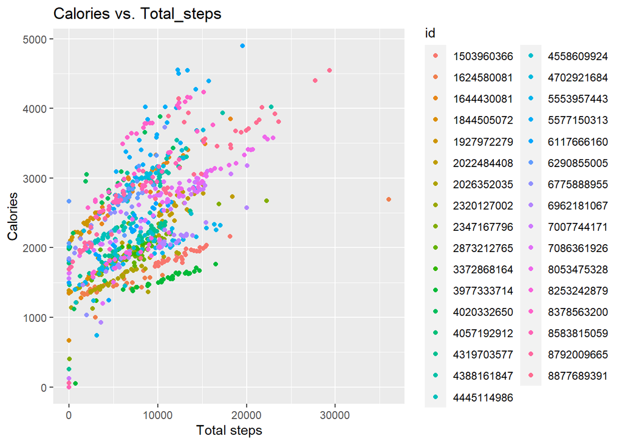

```r
ggplot(data = merged_dataset) + geom_point(aes(x = total_steps , y = calories, color = id)) + labs(x="Total steps", y = "Calories", title="Calories vs. Total_steps")
```

Visual shows a positive correlation between the variables.

```r
write.csv(merged_dataset, "merged_dataset.csv")
```

## The cleaned dataset (*merged_dataset*) is exported, further explored and visualized using a BI tool and to draw further insights from the dataset.